# 07_age_Luise

Sera Choi

13/06/2021

```r
# Load library
library(Seurat)
library(ggplot2)
library(dplyr)
library(here)
library("scales")
library(ggsci)
library(gtools)

# Load data
ec <- readRDS(here("/Users/serachoi/Documents/Edinburgh/MScProject/Project/data/processed/ec05.RDS"))
```

# Differential gene expression with age

This section performs DE analysis on ECs of young and old brain tissues.

Precious study on mouse hippocampus ageing (Brain Endothelial Cells Are Exquisite Sensors of Age- Related Circulatory Cues, 2020) has shown that majority of DEGs were increased upon ageing than decreased.

## Enhanced genes in Old

Overall, 7 genes are expressed higher in old than young that satisfy p-value < 0.05. Of these, only two genes satisfy the pct.1, pct.2 and adjusted p-value thresholds (ACER2, FGD6)

- SLC7A5: An amino acid transporter in BBB, found to be upregulated in breast, prostate and lung cancer
- ACER2: Alkaline ceramidase 2 enhanced in capillary ECs of old mouse hippocampus tissue (Brain Endothelial Cells Are Exquisite Sensors of Age- Related Circulatory Cues, 2020). ACER2 promotes tumour angiogenesis (expansion of capillary network to supply tumour with nutrients and oxygen) (https://doi.org/10.1096/fasebj.25.1_supplement.739.10)
- FGD6: Involved in EC apoptosis during vascular remodeling (infammatory response?)
- TACC1: involved in fibrinolysis, extracellular matrix processing

```r
Idents(ec) <- "AgeGroup"

# enhanced genes in Old individuals
old.markers <- FindMarkers(ec,
                           ident.1 = "Old",
                           ident.2 = "Young",
                           only.pos = TRUE,
                           min.pct = 0.25,
                           logfc.threshold = 0.25,
                           test.use = "MAST")

old.markers <- subset(old.markers, old.markers$p_val_adj < 0.05)

old.markers_sig <- subset(old.markers,
                          old.markers$pct.1 > 0.25 &
                          old.markers$pct.2 < 0.25 )
old.markers
```

```
##               p_val avg_log2FC pct.1 pct.2    p_val_adj
## SLC7A5 9.698168e-10  0.2738277 0.846 0.608 1.869807e-05
## CDK17  3.582531e-07  0.3537587 0.598 0.379 6.907120e-03
## ACER2  4.235311e-07  0.6401274 0.441 0.229 8.165679e-03
## FGD6   7.035701e-07  0.4195119 0.437 0.232 1.356483e-02
## TACC1  7.043144e-07  0.4113652 0.823 0.633 1.357918e-02
## PLAT   1.075578e-06  0.5074965 0.563 0.345 2.073714e-02
## TNRC6B 2.531404e-06  0.5158255 0.626 0.417 4.880547e-02
```

```r
old.markers_sig
```

```
##              p_val avg_log2FC pct.1 pct.2   p_val_adj
## ACER2 4.235311e-07  0.6401274 0.441 0.229 0.008165679
## FGD6  7.035701e-07  0.4195119 0.437 0.232 0.013564831
```

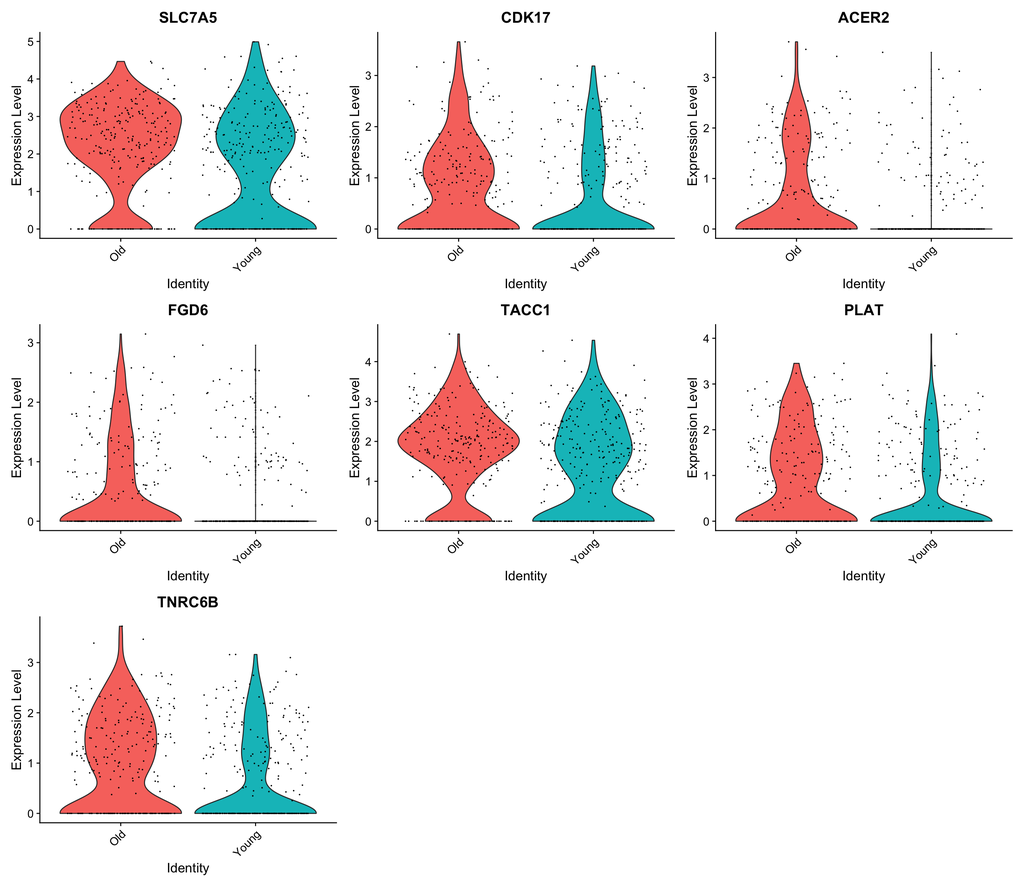

```r
VlnPlot(ec, features = rownames(old.markers), group.by = "AgeGroup")
```